# Using Git in Posit

Levin Wilkinson

2024-01-11

## Introduction

This is a work in progress - I am developing a small guide to using Git in Posit as I’ve had a few questions about it in the past!

Please note: this does not include any info about initially setting up (or cloning) your repo. Please make sure that you have a local copy of the repo and that the remote is set up properly by typing `git remote -v` into the Terminal (Alt+Shift+M). This should give you the URL that you used to set up the repo.

### What is version control?

Version control is a method of saving and storing different versions of files. This is very useful for coding as it allows us to see who else is working on a script, track all changes and (most importantly!) revert the code to a previous version if it is changed or deleted!

### Git vs. GitHub vs. Gitea

These three words are often used to mean the same thing at PHS, but they are all different things:

- Git is a version control system
- [GitHub](https://github.com/) is a public website for hosting code
- [Gitea](https://about.gitea.com/) is a private platform (like Posit Workbench) for hosting more sensitive code and information

### What are shell git commands?

Hopefully, something you won’t need!

Shell commands are commands that you can enter into the Terminal (Alt+Shift+M). There are Terminal commands for everything that you can do with the Posit interface, but there are more specific commands that you can use if things go wrong to reset your code or merge converging branches.

Included in this document are all the commands that are equivalent to things done with the Posit interface, as well as (soon) some links to further reading for debugging and fixing problems!

## Workflow

When you use Git, the recommended workflow is

1. Pull the remote repo
2. Check out the branch you are working on
3. Change the contents of the repository (make changes), then commit and push when the change is complete and the code runs as intended (if you are working on a large task, try to commit small milestones)

Also try to commit and push at the end of a workday (just in case Posit is being dodgy!)

### Steps

#### 1. Pull from remote

The first thing you will need to do is pull from the remote repository. This means taking the latest version of the code from Gitea/GitHub (with any new changes by other people included).

Click the button shown below to pull from the remote repo.

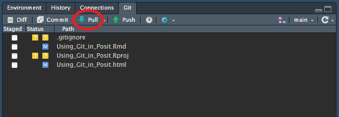

The command line (Terminal) equivalent to this section is `git pull`.

#### 2. Check out

Now we need to ensure we are working on the correct branch. Click the branch name in the top-right corner of the Git tab (this will probably say main or master). This will show you all of the branches available, both locally and remotely.

Click the branch you want to work on to “check out” (switch to it and synchronise with its latest version).

The command line (Terminal) equivalent to this section is `git checkout [branch]` where `[branch]` is the name of your branch.

#### 3. Work and push changes

Please note that the Git tick-box interface is extremely slow. Click once and then wait to see if it responds!

As you work and change files in the repository, they will appear in the Git tab. You can choose which of these files to “save over” by clicking their tick boxes (under Staged).

[figure not shown]

To see a summary of the changes you are about to make, click the Diff button (circled in red above).

##### The Review Changes window

[figure not shown]

This window summarises the changes in each file since the last commit. The coloured letters next to the files explain their status:

- Yellow question marks: this file is untracked - you have not included this file in a previous commit and it has no recorded history. This is usually newly created files (which you should probably add to your commit, which will turn it into a green A) or .gitignore which you don’t have to commit.
- Blue M: this file is being tracked, and has been modified by you since the last commit. If you add these files to the commit, they will be updated on Gitea/GitHub.
- Green A: this file has been added for the first time this commit, and will be tracked from now on.
- Red D: this file is being deleted in this commit and will no longer be tracked or included.
- Purple M: this file has been moved (the original and new locations will be shown)

Enter a commit message (a short note of what you changed, eg. Remove old script) and click the Commit button to commit your changes, and click the Push button to push the changes.

The command line (Terminal) equivalents to this section are:

- `git add -A` to add all files changed or `git add [filepath 1] [filepath 2]` to add specific files
- `git commit -m [commit message]` where `[commit message]` is a description of your changes (e.g. `git commit -m "Fix incorrect header"`) to commit your changes
- `git push` to synchronise your changes with the remote (the database of the code visible to others on GitHub/Gitea)

##### Logging in

At this point, you may be prompted to enter your GitHub/Gitea credentials. I won’t go into too much detail here, but be sure to use your [passkey](https://docs.github.com/en/authentication/authenticating-with-a-passkey/about-passkeys) in the password box, not your password for the website itself.

## Debugging

### Frequently asked questions

#### Why can’t I see the Git tab on the top right window of Posit?

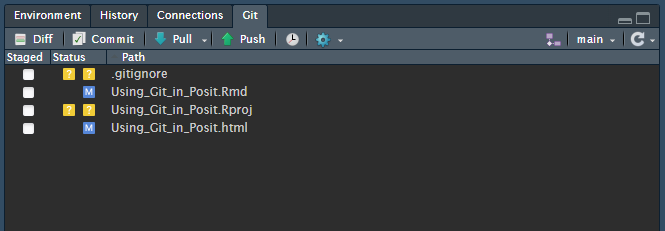

If you can’t see the Git tab in the top-right window of the screen (shown above), check the following:

- You should be in a project in the repository’s home directory (make sure that there is a .Rproj file in the directory and open it)
- Your Posit working directory should be the home directory (run `getwd()` in Console)

## Handy Git Terminal commands

- `git status` to check whether files have been modified/added for a commit
- `git diff [filename]` to see what modifications have been made to a given file since the last commit